# FUSCC - Data Import and Exploration

Charlie Whittaker

03/25/26

# Load Libraries

```r
library(openxlsx)
library(tidyverse)
library(ggrepel)
library(ggpubr)
library(XML)
library(reprex)
library(matrixStats)
library(readxl)

library(Seurat)
library(SeuratWrappers)
#library(Azimuth)
library(patchwork)
library(sctransform)
library(rtracklayer)
library(apeglm)
library(ComplexHeatmap)
library(gprofiler2)
library(cluster)
library(fgsea)
library(SingleCellExperiment)
library(UCell)
library(GSVA)
library(GSEABase)
library(ComplexHeatmap)
library(circlize)
library(grid)

#library(SoupX)
#library(DoubletFinder)
```

# Load Local Code

```r
source('../../Rcode/data_formatting_tools.R')
source('../../Rcode/analysis_tools.R')
source('../../Rcode/plots.R')
source('../../Rcode/common.R')
source('../../Rcode/ssGSEA.Library.R')
```

# Read in FUSCC data

## Gene expression data

```r
fuscc <- read.csv("../../data/FUSCC_EMT/FUSCCTNBC_Expression_RNAseqFPKM.csv")
```

## Annotation of the data

```r
z <- rtracklayer::import("https://ftp.ensembl.org/pub/current_gtf/homo_sapiens/Homo_sapiens.GRCh38.115.chr.gtf.gz")

# tx2gene <- as.data.frame(z) %>% select(c('transcript_id','gene_id'))
# tx2gene <- unique(tx2gene)
# tx2gene <- tx2gene %>% filter(!is.na(transcript_id))
#
gene2typesym <- as.data.frame(z) %>% dplyr::select(c('gene_id','gene_biotype','gene_name'))
gene2typesym <- unique(gene2typesym)
```

```r
# Step 1: Prepare for joining
# Remove rows with NA gene_name from gene2typesym
gene2typesym_clean <- gene2typesym %>%
  dplyr::filter(!is.na(gene_name)) %>%
  dplyr::select(gene_name, gene_biotype)

# Rename X column in fuscc for clarity
fuscc_df <- fuscc %>%
  dplyr::rename(gene_name = X)

# Step 2: Join by gene_name
fuscc_annotated <- fuscc_df %>%
  left_join(gene2typesym_clean, by = "gene_name")

# Step 3: Report on join success
cat("=== GENE BIOTYPE JOIN REPORT ===\n\n")
```

```
## === GENE BIOTYPE JOIN REPORT ===
```

```r
cat("Total rows in fuscc:                  ", nrow(fuscc_df), "\n")
```

```
## Total rows in fuscc:                   23211
```

```r
cat("Total rows in gene2typesym:           ", nrow(gene2typesym), "\n")
```

```
## Total rows in gene2typesym:            78691
```

```r
cat("Rows in gene2typesym (after removing NA):", nrow(gene2typesym_clean), "\n")
```

```
## Rows in gene2typesym (after removing NA): 43030
```

```r
cat("Rows after left_join:                 ", nrow(fuscc_annotated), "\n\n")
```

```
## Rows after left_join:                  24270
```

```r
# Check for matched genes
matched <- sum(!is.na(fuscc_annotated$gene_biotype))
unmatched <- sum(is.na(fuscc_annotated$gene_biotype))

cat("Genes successfully matched:           ", matched, "\n")
```

```
## Genes successfully matched:            15627
```

```r
cat("Genes NOT matched:                    ", unmatched, "\n\n")
```

```
## Genes NOT matched:                     8643
```

```r
# Show breakdown by biotype
cat("Gene biotypes in result:\n")
```

```
## Gene biotypes in result:
```

```r
print(table(fuscc_annotated$gene_biotype, useNA = "ifany"))
```

```
##
##                          IG_C_gene                    IG_C_pseudogene
##                                 13                                  2
##                          IG_V_gene                    IG_V_pseudogene
##                                 84                                  2
##                             lncRNA                              miRNA
##                                141                                  2
##                           misc_RNA               processed_pseudogene
##                                766                                183
##                     protein_coding                               rRNA
##                              13952                                  9
##                    rRNA_pseudogene                             scaRNA
##                                  6                                 13
##                             snoRNA                              snRNA
##                                195                                 62
##                                TEC                          TR_C_gene
##                                  1                                  4
##                          TR_V_gene   transcribed_processed_pseudogene
##                                 21                                 34
##     transcribed_unitary_pseudogene transcribed_unprocessed_pseudogene
##                                 14                                102
##                 unitary_pseudogene             unprocessed_pseudogene
##                                  4                                 17
##                               <NA>
##                               8643
```

```r
# View result
cat("\nFirst few rows of result:\n")
```

```
##
## First few rows of result:
```

```r
print(head(fuscc_annotated[, 1:6]))
```

```
##   gene_name FUSCCTNBC102 FUSCCTNBC103 FUSCCTNBC011 FUSCCTNBC113 FUSCCTNBC116
## 1 5_8S_rRNA            0            0            0            0            0
## 2 5_8S_rRNA            0            0            0            0            0
## 3 5_8S_rRNA            0            0            0            0            0
## 4 5_8S_rRNA            0            0            0            0            0
## 5 5_8S_rRNA            0            0            0            0            0
## 6 5_8S_rRNA            0            0            0            0            0
```

## Select protein coding genes, remove that annotation column

```r
fuscc.coding <- fuscc_annotated %>%
  dplyr::filter(gene_biotype == "protein_coding") %>%
  dplyr::select(-gene_biotype)
```

### Calculate means

```r
fuscc.coding <- mutate(fuscc.coding, Avg = rowMeans(as.matrix(dplyr::select(fuscc.coding, starts_with("FUSCC")), na.rm = TRUE)))
```

### Adding MPG column

Often multiple geneids will map to the same gene symbol. In these cases, it is helpful to select a representative geneID for each group of gene symbols. The code block below iterates through each unique gene symbol, compares all of the geneids associated with the same gene symbol and identifies the geneid with the highest average expression. This gene is then set as the representative (max-per-gene) geneid for that symbol. Note: If multiple geneids have the same highest avg expression, the first gene that appears in the dataframe is taken

```r
mpg <- rep('No', nrow(fuscc.coding))

for (i in unique(fuscc.coding[,"gene_name"])){
    if (is.na(i)){next}
    idxs <- which(fuscc.coding[,"gene_name"] == i)
    max_idx <- which(fuscc.coding$Avg[idxs] == max(fuscc.coding$Avg[idxs]))[1]

    mpg[idxs[max_idx]] <- 'Yes'
}

fuscc.coding$MPG <- mpg
```

### Select only MPG == Yes and remove Avg col

```r
fuscc.coding <- fuscc.coding %>% dplyr::filter(MPG == "Yes") %>% dplyr::select(-Avg,-MPG)
```

### move gene_name to rowname and transform to l2 with +1 offset

```r
fuscc.coding <- fuscc.coding %>% as.data.frame() %>% column_to_rownames("gene_name")
fuscc.coding.l2 <- log2(fuscc.coding+1)
```

### convert to matrix

```r
expr_matrix <- as.matrix(fuscc.coding.l2)
```

## Row-center and transpose the gene expression data for use later

```r
# Remove genes with zero variance BEFORE scaling
gene_sds <- apply(expr_matrix, 1, sd)
expr_matrix.filtered <- expr_matrix[gene_sds > 0, ]

cat("Genes removed (zero variance):", nrow(expr_matrix) - nrow(expr_matrix), "\n")
```

```
## Genes removed (zero variance): 0
```

```r
cat("Genes remaining:", nrow(expr_matrix), "\n")
```

```
## Genes remaining: 13931
```

```r
# Now row-center
expr_matrix.rc <- calculate_zscore(expr_matrix.filtered)

# Verify - should have NO NaN
print(sum(is.nan(expr_matrix.rc)))
```

```
## [1] 0
```

```r
expr_matrix.rc.transposed <- t(expr_matrix.rc)
```

# Gene Sets

```r
Ferroptosis <- c("CBS","PRNP","MAP1LC3B","SLC7A11","ACSL6","SAT2","TF","SLC11A2","CP","FTL","LPCAT3","ATG7","CTH",
                 "CYBB","AKR1C1","AKR1C2","DPP4","ACSL1","ACSL3","ACSL4","FDFT1","SLC39A14","ALOX15","FTH1","GCH1",
                 "NOX1","COQ2","GCLC","GCLM","GPX4","GSS","SLC40A1","HMGCR","HMOX1","HSPB1","IREB2","MAP1LC3C",
                 "NOX4","PCBP1","PCBP2","CHMP5","ACSL5","PHKG2","POR","STEAP3","CISD1","BACH1","SAT1","SLC39A8",
                 "SLC1A5","SLC3A2","TFRC","TP53","TXNRD1","VDAC2","VDAC3","CHMP6","NCOA4","SLC38A1","MAP1LC3A",
                 "AIFM2","AKR1C3","FTMT","ATG5")

Iron_intake <- c("SCARA5","LRP1","CD163","CYBRD1","FRRS1","SLC11A2","FLVCR2","SLC48A1","STEAP1","STEAP2","STEAP3",
                 "STEAP4","TF","TFR2","TFRC","SLC39A8","SLC39A14")

Iron_utilization <- c("FTH1","FTL","HMOX1","HIF1A","EPAS1","HIF3A","SLC25A37","SLC25A28","EGLN2","EGLN1","EGLN3","P4HTM")

Iron_efflux <- c("CP","SLC40A1","HAMP","FLVCR1","HEPH")

Fatty_acid <- c("ACAA1","ACAA2","ACACA","ACACB","ACAD10","ACAD11","ACAD8","ACAD9","ACADL","ACADM","ACADS","ACADSB","ACADVL","ACAT1",
        "ACAT2","ACBD3","ACBD4","ACBD5","ACBD6","ACBD7","ACOX1","ACOX2","ACOX3","ACOXL","ACSBG1","ACSBG2","ACSF2","ACSF3",
        "ACSL1","ACSL3","ACSL4","ACSL5","ACSL6","ACSM1","ACSM2A","ACSM2B","ACSM3","ACSM4","ACSM5","ACSS1","ACSS2","ACSS3",
        "CLYBL","CPT1A","CPT1B","CPT1C","CPT2","CYP4A11","CYP4A22","CYP4B1","CYP4F11","CYP4F12","CYP4F2","CYP4F22","CYP4F3",
        "CYP4F8","CYP4V2","CYP4X1","CYP4Z1","DCI","DECR1","DECR2","DGAT1","DGAT2","DGAT2L3","DGAT2L4","DGAT2L6","DGAT2L7",
        "ECH1","ECHDC1","ECHDC2","ECHDC3","ECHS1","EHHADH","ELOVL1","ELOVL2","ELOVL3","ELOVL4","ELOVL5","ELOVL6","ELOVL7",
        "ETFA","ETFB","ETFDH","FA2H","FAAH","FAAH2","FADS1","FADS2","FADS3","FAR1","FAR2","FASN","GPSN2","HACL1","HADH",
        "HADHA","HADHB","LIPC","LIPF","LIPG","LIPH","LIPI","LIPJ","LIPK","LIPM","LIPN","LPL","LPPR2","MCAT","MECR","MGLL",
        "MLYCD","MTTP","OLAH","OXSM","PECI","PECR","PHYH","PHYHD1","PNLIP","PNLIPRP1","PNLIPRP2","PNLIPRP3","PNPLA1",
        "PNPLA2","PNPLA3","PNPLA4","PNPLA5","PNPLA6","PNPLA7","PNPLA8","SCD","SCD5","SCP2","SDR16C6","SDR39U1","SDR42E1","SDR9C7")

Fatty_acid_uptake <- c("CD36","FABP4","SLC27A1","CAV1")

Unsaturated_FA_biosynthetic_process <- c("ABCD1","ABCD2","AKR1C3","ALOX12","ALOX15","ALOX15B","ANXA1","AVP","AVPR1A",
                                         "CBR1","CD74","DAGLB","DECR2","DEGS1","EDN1","EDN2","ELOVL1","ELOVL2","ELOVL3",
                                         "ELOVL4","ELOVL5","ELOVL6","ELOVL7","FABP5","FADS1","FADS2","FADS2B","FADS3",
                                         "HPGDS","IL1B","MIF","MIR132","MIR204","MIR766","PIBF1","PLA2G3","PLA2G4A","PLA2G4F",
                                         "PNPLA8","PRXL2B","PTGDS","PTGES","PTGES2","PTGES3","PTGIS","PTGS1","PTGS2","SCD",
                                         "SCD5","SIRT1","TBXAS1")

Membrane_Lipid <- c("AGPAT1","AGPAT2","AGPAT3","AGPAT4","AGPAT5","AGPAT6","AGPAT9","CDS1","CDS2","CEPT1","CHKA","CHKB","CHPT1",
                    "CLC","CRLS1","CROT","DAGLA","DAGLB","DGKA","DGKB","DGKD","DGKE","DGKG","DGKH","DGKI","DGKK","DGKQ","DGKZ",
                    "ETNK1","ETNK2","GDE1","GK","GK2","GK5","GNPAT","GPAM","GPD1","GPD1L","GPD2","LPCAT1","LPCAT2","LPCAT3",
                    "LPCAT4","LPGAT1","LPIN1","LPIN2","LPIN3","LYPLA1","LYPLA2","LYPLAL1","MBOAT1","MBOAT2","MBOAT4","MBOAT7",
                    "MOGAT1","MOGAT2","MOGAT3","NAPE-PLD","PAP2D","PCYT1A","PCYT1B","PCYT2","PEMT","PGS1","PHOSPHO1","PISD",
                    "PLA1A","PLA2G10","PLA2G12A","PLA2G12B","PLA2G15","PLA2G16","PLA2G1B","PLA2G2A","PLA2G2C","PLA2G2D","PLA2G2E",
                    "PLA2G2F","PLA2G3","PLA2G4A","PLA2G4B","PLA2G4C","PLA2G4D","PLA2G4E","PLA2G4F","PLA2G5","PLA2G6","PLA2G7",
                    "PLB1","PLCB1","PLCB2","PLCB3","PLCB4","PLCD1","PLCD3","PLCD4","PLCE1","PLCG1","PLCG2","PLCH1","PLCH2",
                    "PLCL1","PLCL2","PLCXD1","PLCXD2","PLCXD3","PLCZ1","PLD1","PLD2","PLD3","PLD4","PLD5","PLD6","PPAP2A",
                    "PPAP2B","PPAP2C","PPAPDC1A","PPAPDC1B","PPAPDC2","PPAPDC3","PRG2","PTDSS1","PTDSS2")

Redox <- c("CP","CRYZ","CRYZL1","CYB561","CYB5A","CYB5B","CYB5D1","CYB5D2","CYB5R1","CYB5R2","CYB5R3","CYB5R4","CYB5RL","CYBA",
           "CYBASC3","CYBB","CYBRD1","DHRS1","DHRS11","DHRS12","DHRS13","DHRS2","DHRS3","DHRS4","DHRS4L1","DHRS4L2","DHRS7",
           "DHRS7B","DHRS7C","DHRS9","DHRSX","DHTKD1","ENOX1","ENOX2","FDX1","FDX1L","FDXR","FOXRED1","FOXRED2","FRRS1","GLRX",
           "GLRX2","GLRX3","GLRX5","GRXCR1","GRXCR2","ISCA1","ISCA1L","ISCA2","LPO","MICAL1","MICAL2","MICAL3","NDOR1","NMRAL1",
           "OGFOD1","OGFOD2","OXA1L","PRDX1","PRDX2","PRDX3","PRDX4","PRDX5","PRDX6","PYROXD1")

# Ferroptosis_pathways2

Complex_I_IV <- c("MT-ND1","MT-ND2","MT-ND3","MT-ND4","MT-ND4L","MT-ND5","MT-ND6","NDUFA1","NDUFA10","NDUFA11","NDUFA12",
                  "NDUFA13","NDUFA2","NDUFA3","NDUFA4","NDUFA4L","NDUFA4L2","NDUFA5","NDUFA6","NDUFA7","NDUFA8","NDUFA9",
                  "NDUFAB1","NDUFAF1","NDUFAF2","NDUFB1","NDUFB10","NDUFB11","NDUFB2","NDUFB3","NDUFB4","NDUFB5","NDUFB6",
                  "NDUFB7","NDUFB8","NDUFB9","NDUFC1","NDUFC2","NDUFS1","NDUFS2","NDUFS3","NDUFS4","NDUFS5","NDUFS6","NDUFS7",
                  "NDUFS8","NDUFV1","NDUFV2","NDUFV3","SDHA","SDHB","SDHC","SDHD","CYC1","CYCS","MT-CYB","UCRC","UQCR",
                  "UQCRB","UQCRC1","UQCRC2","UQCRFS1","UQCRH","UQCRQ","COX1","COX10","COX11","COX15","COX16","COX17","COX18",
                  "COX19","COX2","COX3","COX4I1","COX4I2","COX5A","COX5B","COX6A1","COX6A2","COX6B1","COX6B2","COX6C","COX7A1",
                  "COX7A2","COX7A2L","COX7B","COX7B2","COX7C","COX8A","COX8C")

Reactive_oxygen_species_pathway <- c("ABCC1","ATOX1","CAT","CDKN2D","EGLN2","ERCC2","FES","FTL","G6PD","GCLC","GCLM","GLRX",
                                     "GLRX2","GPX3","GPX4","GSR","HHEX","HMOX2","IPCEF1","JUNB","LAMTOR5","LSP1","MBP","MGST1",
                                     "MPO","MSRA","NDUFA6","NDUFB4","NDUFS2","NQO1","OXSR1","PDLIM1","PFKP","PRDX1","PRDX2",
                                     "PRDX4","PRDX6","PRNP","PTPA","SBNO2","SCAF4","SELENOS","SOD1","SOD2","SRXN1","STK25",
                                     "TXN","TXNRD1","TXNRD2")
```

```r
LOXs <- c("ALOX12","ALOX12B","ALOX15","ALOX15B","ALOX5","ALOX5AP","ALOX8","ALOXE3")

BH4 <- c("GCH1","PTS","QDPR","SPR")

Folate <- c("DHFR","DHFRL1","FPGS","MTHFD1","MTHFD1L","MTHFD2","MTHFD2L","MTHFR","MTHFS","MTHFSD","SHMT1","SHMT2")

Glutathione <- c("GCLC","GCLM","GPX1","GPX2","GPX3","GPX4","GPX5","GPX6","GPX7","GPX8","GSR","GSS","GSTA1","GSTA2","GSTA3",
                 "GSTA4","GSTA5","GSTCD","GSTK1","GSTM1","GSTM2","GSTM3","GSTM4","GSTM5","GSTO1","GSTO2","GSTP1","GSTT1",
                 "GSTT2","HAGH","HAGHL","MGST1","MGST2","MGST3")

CoQ10 <- c("PDSS1","PDSS2","COQ2","COQ3","COQ6","COQ5","COQ7","COQ8A","COQ9","COQ8B")

Thioredoxin <- c("TXNRD1","TXNRD2","TXNRD3","NXN","TXN","SELENOT","TXNDC2","PRDX1","PRDX2","PRDX3","PRDX4","PRDX5")

Glutamate_transmembrane <- c("ARL6IP1","ARL6IP5","ATP1A2","CLN8","GRM1","ITGB1","KCNJ10","NTSR1","PER2","PRAF2","PSEN1",
                             "SLC17A6","SLC17A7","SLC17A8","SLC1A1","SLC1A2","SLC1A3","SLC1A6","SLC1A7","SLC25A12","SLC25A13",
                             "SLC25A18","SLC25A22","SLC38A7","SLC7A11")

homocysteine_metabolic_process <- c("BHMT","BLMH","CBS","CBSL","CPS1","CTH","DPEP1","MMUT","MPST","MTHFR","MTRR","NOX4","TST")

Pentose_Phosphate <- c("DERA","G6PD","PGD","PGLS","RPE","RPIA","TALDO1","TKT","TKTL1","TKTL2")

Glycolysis <- c("ADPGK","ALDOA","ALDOB","ALDOC","BPGM","DLAT","ENO1","ENO2","ENO3","GAPDH","GAPDHS","GCK","GPI","HK1","HK2",
                "HK3","HKDC1","PDHA1","PDHA2","PDHB","PDHX","PFKFB1","PFKFB2","PFKFB3","PFKFB4","PFKL","PFKM","PFKP","PGAM1",
                "PGAM2","PGAM4","PGAM5","PGK1","PGK2","PGM1","PGM2","PGM2L1","PGM5","PKLR","PKM2","TPI1")

Krebs <- c("ACLY","ACO1","ACO2","CS","D2HGDH","DLST","FH","HCCS","IDH1","IDH2","IDH3A","IDH3B","IDH3G","L2HGDH","MDH1","MDH1B",
           "MDH2","ME1","ME2","ME3","OGDH","OGDHL","PC","SUCLA2","SUCLG1","SUCLG2")

# EMT and Others

EMT.Klughammer <- c("IGFBP7","SPARC","COL1A2","COL4A1","COL3A1","BGN","ACTA2","FN1","COL4A2","TAGLN",
                    "DCN","COL1A1","LUM","COL6A3","POSTN","AEBP1","COL6A2","VIM","TIMP1","TPM2","COL5A1",
                    "CALD1","COL6A1","A2M","SPARCL1","THY1","VCAN","CCN2","GNG11","PDGFRB","RGS5",
                    "ITGA1","MYL9","COL5A2","COL18A1","THBS2","IGHA1","CAVIN1","ELN","NID1","LHFPL6",
                    "APOE","IGLC3","HSPG2","CAV1","TCF4","NNMT","ASPN","FSTL1","MGP")

EMT.Hallmark <- c("ABI3BP", "ACTA2","ADAM12","ANPEP","APLP1","AREG","BASP1","BDNF","BGN","BMP1",
                  "CADM1","CALD1","CALU","CAP2","CAPG","CCN1","CCN2","CD44","CD59","CDH11","CDH2",
                  "CDH6","COL11A1","COL12A1","COL16A1","COL1A1","COL1A2","COL3A1","COL4A1","COL4A2",
                  "COL5A1","COL5A2","COL5A3","COL6A2","COL6A3","COL7A1","COL8A2","COLGALT1","COMP",
                  "COPA","CRLF1","CTHRC1","CXCL1","CXCL12","CXCL6","CXCL8","DAB2","DCN","DKK1","DPYSL3",
                  "DST","ECM1","ECM2","EDIL3","EFEMP2","ELN","EMP3","ENO2","FAP","FAS","FBLN1","FBLN2",
                  "FBLN5","FBN1","FBN2","FERMT2","FGF2","FLNA","FMOD","FN1","FOXC2","FSTL1","FSTL3",
                  "FUCA1","FZD8","GADD45A","GADD45B","GAS1","GEM","GJA1","GLIPR1","GPC1","GPX7",
                  "GREM1","HTRA1","ID2","IGFBP2","IGFBP3","IGFBP4","IL15","IL32","IL6","INHBA","ITGA2",
                  "ITGA5","ITGAV","ITGB1","ITGB3","ITGB5","JUN","LAMA1","LAMA2","LAMA3","LAMC1","LAMC2",
                  "LGALS1","LOX","LOXL1","LOXL2","LRP1","LRRC15","LUM","MAGEE1","MATN2","MATN3","MCM7",
                  "MEST","MFAP5","MGP","MMP1","MMP14","MMP2","MMP3","MSX1","MXRA5","MYL9","MYLK","NID2",
                  "NNMT","NOTCH2","NT5E","NTM","OXTR","P3H1","PCOLCE","PCOLCE2","PDGFRB","PDLIM4","PFN2",
                  "PLAUR","PLOD1","PLOD2","PLOD3","PMEPA1","PMP22","POSTN","PPIB","PRRX1","PRSS2","PTHLH",
                  "PTX3","PVR","QSOX1","RGS4","RHOB","SAT1","SCG2","SDC1","SDC4","SERPINE1","SERPINE2",
                  "SERPINH1","SFRP1","SFRP4","SGCB","SGCD","SGCG","SLC6A8","SLIT2","SLIT3","SNAI2",
                  "SNTB1","SPARC","SPOCK1","SPP1","TAGLN","TFPI2","TGFB1","TGFBI","TGFBR3","TGM2",
                  "THBS1","THBS2","THY1","TIMP1","TIMP3","TNC","TNFAIP3","TNFRSF11B","TNFRSF12A",
                  "TPM1","TPM2","TPM4","VCAM1","VCAN","VEGFA","VEGFC","VIM","WIPF1","WNT5A")

EMT.prelim <- c("VIM","ZEB1","ZEB2","ITGA2")

EMT.76gs <- c("CHEK2","FZR1","CHAF1B","CDS1","AP1M2","FN1","EPPK1","BSPRY","HNMT","PRR5","ST14","EPN3","ZEB1",
              "CLDN7","SH3YL1","PRSS22","TGFBI","CRB3","MUC1","DSP","RBPMS","ELMO3","CLDN4","ENPP5","EPB41L5",
              "MPZL2","EPHA1","PPARG","RAB25","CARD6","SCNN1A","ERBB3","SPINT2","EVPL","TACSTD2","TMC4","CDH1",
              "TNFRSF21","FXYD3","MPP7","GALNT3","GALNT5","NRP1","AXL","PRSS8","GRHL1","GRHL2","S100A14","CDH3",
              "SERINC2","SHROOM3","ITGB6","SSH3","KLC3","STAP2","ANTXR2","ANKRD22","TJP3","LIX1L","TMEM125",
              "TMEM45B","MAL2","VIM","MAPK13","MMP2","KRT19","KRTCAP3","ESRP1","XXYLT1","TC2N","ADGRF1","ADGRG1",
              "S100A11P1","CDH15","PATJ","TSKU")

EMT.MLR_method <- c("FZR1","PAPPA-AS1","CCM2","CDKN2AIP","CLDN7","VIM","CDH1","GRHL2","OVOL1","SLC25A42","SNX13",
                   "TAF4B","CRIP2","CDK2","MBNL1","NEURL1B","ANG","RNASE4","PPFIBP1","PACSIN1","LRRTM1","TMEM182",
                   "CSMD1","ZNF503-AS2","CCNF","DIRC1","MBTPS2","RNF150","RC3H2","UBE3C","HUNK","CEP135","SAFB2",
                   "OSM","MTAP","PDS5B","ACTN4","AFF3","THAP4","ZNF490","CLU","GGCX","CARF","REXO2","LIG3",
                   "SRD5A3-AS1","FZD10-AS1","ADAMTS7P3","ADAMTS7","MIAT","COG1","CD47","PLEKHB2","BAIAP2-DT")

EMT.cell_line.epi <- c("CDH1","AGR2","EPCAM","KRT19","RAB25","TACSTD2","S100P","CEACAM6","GALNT3","FXYD3","SPINT2",
                       "TMEM30B","SCNN1A","ST14","ESRP1","S100A14","CLDN7","ERBB3","RBM47","SPINT1","ELF3","CLDN4",
                       "PRSS8","SH3YL1","EHF","LCN2","JUP","VAMP8","KRT8","C1orf106","KRT7","DSP","CDS1","ITGB4",
                       "TMPRSS4","LSR","SORL1","GRHL2","PPL","C1orf116","TSPAN1","MAP7","SLPI","TOX3","ARHGAP8","F11R",
                       "LAD1","GPX2","CTSH","GPR56","FA2H","KLF5","AREG","KRT18","SCEL","CDH3","UGT1A1","MPZL2","AIM1",
                       "OVOL2","LLGL2","ESRP2","MYO5C","DDR1","VGLL1","IRF6","SFN","TSPAN13","KCNK1","MYO1D","PKP3",
                       "ITGB6","LY75","MAPK13","TTC39A","ELMO3","CEACAM1","DTX4","ERBB2","RAB11FIP1","ATP2C2","MST1R",
                       "AP1M2","TGFA","MYO6","PTK6","OAS1","FBP1","AQP3","CBLC","EPHA1","BSPRY","SH2D3A","EPS8L1","GRB7",
                       "C4orf19","KLK6","TJP2","PLS1","DENND2D","EPS8L2","IL20RA","HES1","IL1RN","EXPH5","ARHGDIB",
                       "C19orf21","CAMK2N1","HPGD","SYNGR2","C10orf116","PERP","MANSC1","DSC2","POF1B","SERINC5","BIK",
                       "ANXA9","MALL","EPN3","STAP2","FOXA1","PYCARD","ZNF165","SLC37A1","ANK3","TSPAN15","HNMT","ABCC3",
                       "SDC1","CKMT1A","TOB1","B3GNT3","TMC6","CD9","ADAP1","ATP1B1","SHANK2","CYB561","ERMP1","RAB20",
                       "MYH14","CAPN1","ALDH3B2","TRIM31","ARAP2","SSH3","ICA1","ARHGEF5","ALOX5","RHOD","TMPRSS2","MTUS1",
                       "CYP4F3","PPFIBP2","RABGAP1L","PLXNB2","MGST2","OR7E14P","EVPL","CD46","KRT15","CNKSR1","BLNK",
                       "COMT","ANXA4","TNFSF13","OCLN","SLC9A3R1","XBP1")
```

```r
EMT.cell_line.mes <- c("VIM","ZEB1","EMP3","SACS","AXL","LOXL2","SPARC","FHL1","FERMT2","TUBA1A","TMEM158","CALD1",
                       "LGALS1","PMP22","MSN","GLYR1","MAP1B","AP1S2","GJA1","DENND5A","C12orf24","TPM2","TUBB6",
                       "SRPX","ANK2","CHN1","SH2B3","LEPRE1","ETV1","SOBP","AKAP12","TGFB1I1","SERPINE1","SOAT1",
                       "COL5A2","LHFP","CEP170","POPDC3","TRPC1","KDELC1","MYL9","BAG2","FSTL1","MXRA7","GFPT2",
                       "RECK","TMEFF1","PTRF")

EMT.tumor.epi <- c("KRT19","AGR2","RAB25","CDH1","ERBB3","FXYD3","SLC44A4","S100P","SCNN1A","GALNT3","PRSS8","ELF3",
                   "CEACAM6","TMPRSS4","CLDN7","TACSTD2","CLDN3","EPCAM","SPINT1","TSPAN1","PLS1","TMEM30B","PRR15L",
                   "KRT8","ST14","RBM47","S100A14","C1orf106","NQO1","TOX3","PTK6","TFF1","CLDN4","GPRC5A","TJP3",
                   "KRT18","MAP7","CKMT1A","ESRP1","MUC1","SPINT2","ESRP2","CDS1","PPAP2C","CEACAM7","TTC39A","OVOL2",
                   "EHF","AP1M2","CEACAM5","LAD1","ARHGAP8","TFF3","JUP","CD24","TMC5","MLPH","ELMO3","ERBB2","LLGL2",
                   "DDR1","FA2H","CBLC","TMPRSS2","LSR","PERP","POF1B","MYO5C","RAB11FIP1","MAPK13","KRT7","CEACAM1",
                   "CXADR","ATP2C2","RNF128","MPZL2","EPS8L1","GALNT7","CORO2A","BCAS1","TPD52","ARHGAP32","FUT2",
                   "OR7E14P","GALE","GRHL2","BIK","RAPGEFL1","STYK1","F11R","PKP3","CYB561","SH3YL1","GDF15","PSCA",
                   "EZR","TJP2","FGFR3","FUT3","BSPRY","TOM1L1  ","IRF6","EPB41L4B","OCLN","LRRC1","C19orf21",
                   "ABHD11","EPS8L2","MYO6","TSPAN8","MST1R","SLC16A5","GPR56","AZGP1","TOB1","SLC35A3","TRPM4",
                   "PHLDA2","VAMP8","SLC22A18","AKR1B10","VAV3","SPAG1","ABCC3","SYNGR2","STAP2","C4orf19","PPL",
                   "PLLP","DSG2","HDHD3","CD2AP","MANSC1","DHCR24","EPN3","TUFT1","GMDS","EXPH5","DSP","SDC4","IL20RA",
                   "FAM174B","PTPRF","SORD")

EMT.tumor.mes <- c("GAS1","CXCL12","ZEB1","GLYR1","FHL1","FERMT2","C1S","FYN","WIPF1","CYP1B1","SERPING1","SERPINF1",
                   "VCAM1","MAP1B","TCF4","SRPX","EMP3","DPT","CALD1","PTGIS","VIM","CD163","C1R","FBN1","FN1","FXYD6",
                   "IGF1","NAP1L3","MRC1","QKI","MS4A4A","DCN","LOX","RECK","ANK2","LY96","ZFPM2","CSRP2","EFEMP1",
                   "RARRES2","PTPRC","PLEKHO1","RGS2","F13A1","JAM2","CHRDL1","TUBA1A","AP1S2","MYLK","DDR2","DSE",
                   "SACS","GLIPR1","CXCL13","FLRT2","PTX3","AKT3","COL6A2","DPYSL3","CDH11","PDZRN3","ZEB2","CCL2",
                   "MAFB","SFRP1","C14orf139","MFAP4","MAF","UCHL1","TUBB6","SRGN","HEG1","KCNJ8","AKAP12","EVI2A",
                   "COL14A1","AXL","ECM2","FSTL1","PLN","MYL9","OLFML3","STON1","SLIT2","BICC1","SOBP","CLIC4","ENPP2",
                   "SAMSN1","TPM2","ASPN","COL6A1","IGFBP5","MOXD1","AKAP2","SLC2A3","OLFML2B","ANGPTL2","PCOLCE",
                   "COLEC12","CTSK","TAGLN","CDH2","IL10RA","C1orf54","CEP170","TNS1","CLEC2B","JAM3","SEPT6","GREM1",
                   "VCAN","ZCCHC24","CRYAB","SFRP4","RUNX1T1","FGL2","MS4A6A","PTRF","GIMAP4","TWIST1","GFPT2","LHFP",
                   "CXCR4","SPOCK1","SPARC","VSIG4","GPM6B","TRPC1","SNAI2","GUCY1B3","PLXNC1","SYT11","FLI1","MYH10",
                   "CSF2RB","TNC","PMP22","COL5A2","MMP2","GNG11","CAV1","CDK14","SDC2","PTGDS","NR3C1","SYNM","FAP",
                   "NUAK1","WWTR1","FBLN1","MPDZ","SYNE1","EFEMP2","GIMAP6","KIAA1462","CCL8","COL15A1","CHN1","CRISPLD2",
                   "PDGFC","GEM","ISLR","GZMK","SPARCL1","BNC2","BGN","MEOX2","ITM2A","IFFO1")

LAM <- c("TREM2","APOE","C1Q2A","C1QB","C1QC","CD9","CD163")

exhausted.CD8 <- c("PDCD1","CTLA4","LAG3","HAVCR2","TIGIT","TOX","EOMES","TBX21","CXCL13","CD244")
```

## Score gene sets for heatmap using gsva

```r
gsva_params <- gsvaParam(exprData = expr_matrix,
                         geneSets = list(
                           Fatty_acid_uptake.gsva = Fatty_acid_uptake,
                           LOXs.gsva = LOXs,
                           Thioredoxin.gsva = Thioredoxin,
                           Glutamate_transmembrane.gsva = Glutamate_transmembrane,
                           Membrane_Lipid.gsva = Membrane_Lipid,
                           Unsat_FA_biosynth_process.gsva = Unsaturated_FA_biosynthetic_process,
                           Fatty_acid.gsva = Fatty_acid,
                           Iron_intake.gsva = Iron_intake,
                           Iron_utilization.gsva = Iron_utilization,
                           Glutathione.gsva = Glutathione,
                           BH4.gsva = BH4,
                           CoQ10.gsva = CoQ10
                         ))

Heatmap.GSVA.scores <- gsva(gsva_params)
```

### Transpose gsva scores

```r
Heatmap.GSVA.scores.transposed <- t(Heatmap.GSVA.scores)
```

# EMT scoring with Chakraborty KS methd

## Import KS code

```r
source("../../emt_code/Chakraborty_et_al_KS_code_vCAW.R")
```

## Point to signature file

```r
KSScore.EMTSignature.file = "../../emt_code/EM_gene_signature_tumor_KS.xlsx"
```

## Calculate KS

```r
fuscc.ks.emt <- KSScore(expr_matrix,"fuscc",".")
```

```
## Calculating EMT Score by KS score method ....
## [1] 290 360
```

```r
fuscc.ks.emt <- as.data.frame(fuscc.ks.emt)
```

# Combine data for plotting

```r
# Convert all to dataframes with rownames as column
gsva_df <- as.data.frame(Heatmap.GSVA.scores.transposed) %>%
  rownames_to_column("Sample")
expr_df <- as.data.frame(expr_matrix.rc.transposed) %>%
  rownames_to_column("Sample")
met_df <- as.data.frame(fuscc.ks.emt) %>%
  rownames_to_column("Sample")

# Join all three by Sample
merged_all <- gsva_df %>%
  inner_join(expr_df, by = "Sample") %>%
  inner_join(met_df, by = "Sample")

# Convert Sample back to rownames
rownames(merged_all) <- merged_all$Sample
merged_all <- merged_all %>% dplyr::select(-Sample)

# Report on join success
cat("=== THREE-WAY JOIN REPORT ===\n\n")
```

```
## === THREE-WAY JOIN REPORT ===
```

```r
cat("Rows in GSVA scores:                  ", nrow(gsva_df), "\n")
```

```
## Rows in GSVA scores:                   360
```

```r
cat("Rows in expression matrix:            ", nrow(expr_df), "\n")
```

```
## Rows in expression matrix:             360
```

```r
cat("Rows in fuscc.ks.emt:                ", nrow(met_df), "\n")
```

```
## Rows in fuscc.ks.emt:                 360
```

```r
cat("Rows after inner_join:                ", nrow(merged_all), "\n\n")
```

```
## Rows after inner_join:                 360
```

```r
# Check for unmatched
unmatched_gsva <- anti_join(gsva_df, expr_df, by = "Sample") %>%
  anti_join(met_df, by = "Sample")
unmatched_expr <- anti_join(expr_df, gsva_df, by = "Sample") %>%
  anti_join(met_df, by = "Sample")
unmatched_met <- anti_join(met_df, gsva_df, by = "Sample") %>%
  anti_join(expr_df, by = "Sample")

cat("Samples in GSVA but NOT in others:    ", nrow(unmatched_gsva), "\n")
```

```
## Samples in GSVA but NOT in others:     0
```

```r
cat("Samples in expr but NOT in others:    ", nrow(unmatched_expr), "\n")
```

```
## Samples in expr but NOT in others:     0
```

```r
cat("Samples in met but NOT in others:     ", nrow(unmatched_met), "\n\n")
```

```
## Samples in met but NOT in others:      0
```

```r
# Success status
if (nrow(merged_all) > 0) {
  cat("✓ SUCCESS: Join completed!\n")
  cat("  Final dimensions: ", nrow(merged_all), " samples × ", ncol(merged_all), " variables\n\n")
} else {
  cat("✗ ERROR: No matching samples found!\n")
}
```

```
## ✓ SUCCESS: Join completed!
##   Final dimensions:  360  samples ×  13944  variables
```

```r
# View result
cat("Final structure:\n")
```

```
## Final structure:
```

```r
print(head(merged_all[, 1:8]))
```

```
##              Fatty_acid_uptake.gsva     LOXs.gsva Thioredoxin.gsva
## FUSCCTNBC102             -0.7922022 -0.5661754370        0.4105817
## FUSCCTNBC103             -0.2815572 -0.2598547340        0.1506202
## FUSCCTNBC011             -0.7764055  0.0004244222        0.2322013
## FUSCCTNBC113             -0.4083946 -0.7429451931        0.1505064
## FUSCCTNBC116             -0.1985603 -0.1300826858        0.3615765
## FUSCCTNBC129              0.4020234 -0.2744509031        0.1070208
##              Glutamate_transmembrane.gsva Membrane_Lipid.gsva
## FUSCCTNBC102                   0.19706430          0.03838659
## FUSCCTNBC103                   0.27265309          0.02717360
## FUSCCTNBC011                  -0.06455139         -0.01728890
## FUSCCTNBC113                   0.10822744          0.09072305
## FUSCCTNBC116                   0.13800390         -0.24553243
## FUSCCTNBC129                   0.29116559         -0.12173133
##              Unsat_FA_biosynth_process.gsva Fatty_acid.gsva Iron_intake.gsva
## FUSCCTNBC102                     0.11544238      0.03570793       0.06365962
## FUSCCTNBC103                    -0.28430616     -0.31145375       0.11928220
## FUSCCTNBC011                     0.23677353     -0.03213064       0.19431831
## FUSCCTNBC113                    -0.23385347      0.20939494      -0.05768914
## FUSCCTNBC116                    -0.01469659     -0.24455099       0.15194494
## FUSCCTNBC129                     0.02923408      0.02798707       0.11239310
```

## Gene set scatter plots

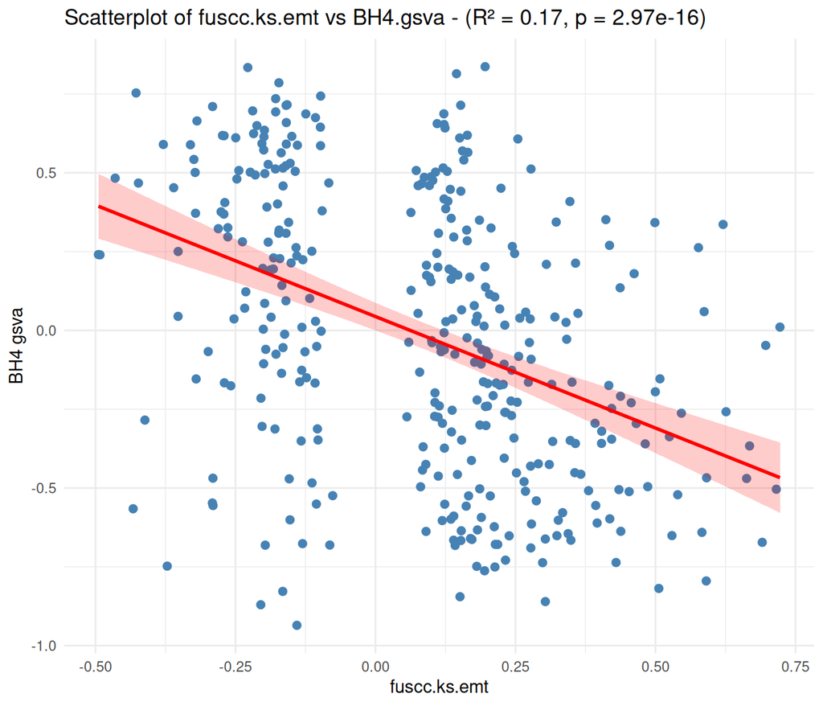

```r
# Helper function to get correlation statistics
get_cor_stats <- function(x, y) {
  # Remove NA values
  idx <- !is.na(x) & !is.na(y)
  x <- x[idx]
  y <- y[idx]

  # Calculate correlation
  cor_test <- cor.test(x, y, method = "pearson")
  r_squared <- cor_test$estimate^2
  p_value <- cor_test$p.value

  return(list(r_squared = r_squared, p_value = p_value))
}

# Plot 1: BH4.gsva
stats1 <- get_cor_stats(merged_all$fuscc.ks.emt, merged_all$BH4.gsva)
title1 <- sprintf("Scatterplot of fuscc.ks.emt vs BH4.gsva - (R² = %.2f, p = %.2e)",
                  stats1$r_squared, stats1$p_value)

BH4.scatter <- ggplot(merged_all, aes(x = fuscc.ks.emt, y = BH4.gsva)) +
  geom_point(color = "steelblue", size = 2) +
  geom_smooth(method = "lm", se = TRUE, color = "red", fill = "red", alpha = 0.2) +
  labs(
    title = title1,
    x = "fuscc.ks.emt",
    y = "BH4 gsva"
  ) +
  theme_minimal()
BH4.scatter
```

```r
pdf("bh4_scatter.pdf", width = 6, height = 7)
BH4.scatter
dev.off()
```

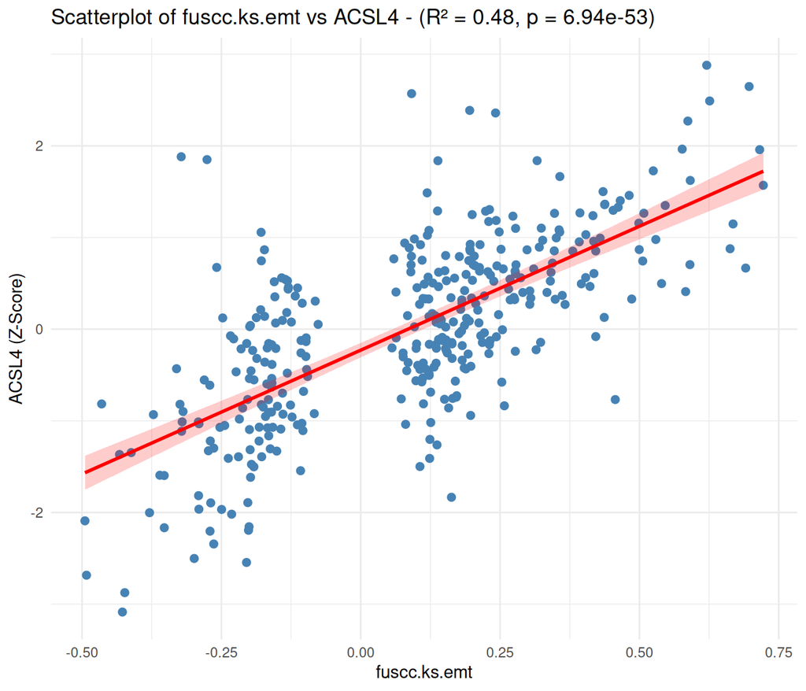

```r
# Plot 2: ACSL4
stats2 <- get_cor_stats(merged_all$fuscc.ks.emt, merged_all$ACSL4)
title2 <- sprintf("Scatterplot of fuscc.ks.emt vs ACSL4 - (R² = %.2f, p = %.2e)",
                  stats2$r_squared, stats2$p_value)

ggplot(merged_all, aes(x = fuscc.ks.emt, y = ACSL4)) +
  geom_point(color = "steelblue", size = 2) +
  geom_smooth(method = "lm", se = TRUE, color = "red", fill = "red", alpha = 0.2) +
  labs(
    title = title2,
    x = "fuscc.ks.emt",
    y = "ACSL4 (Z-Score)"
  ) +
  theme_minimal()
```

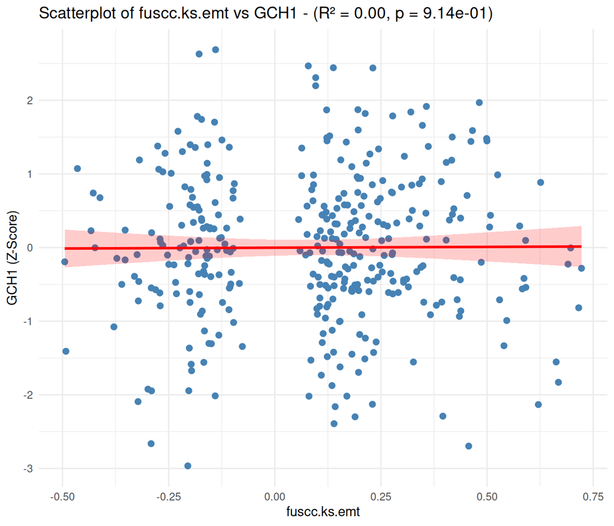

```r
# Plot 3: GCH1
stats3 <- get_cor_stats(merged_all$fuscc.ks.emt, merged_all$GCH1)
title3 <- sprintf("Scatterplot of fuscc.ks.emt vs GCH1 - (R² = %.2f, p = %.2e)",
                  stats3$r_squared, stats3$p_value)

ggplot(merged_all, aes(x = fuscc.ks.emt, y = GCH1)) +
  geom_point(color = "steelblue", size = 2) +
  geom_smooth(method = "lm", se = TRUE, color = "red", fill = "red", alpha = 0.2) +
  labs(
    title = title3,
    x = "fuscc.ks.emt",
    y = "GCH1 (Z-Score)"
  ) +
  theme_minimal()
```

# Prepare Heatmap version 1

## Select data to plot

```r
merged_all.df <- merged_all %>% rownames_to_column("Sample")

heat.data <- merged_all.df %>%
  dplyr::select(all_of(c("Sample",
                         "fuscc.ks.emt",
                         "Fatty_acid_uptake.gsva",
                         "LOXs.gsva", "Iron_intake.gsva", "Membrane_Lipid.gsva", "Unsat_FA_biosynth_process.gsva", "Fatty_acid.gsva",
                         "Iron_utilization.gsva", "Glutathione.gsva", "BH4.gsva", "Thioredoxin.gsva","Glutamate_transmembrane.gsva","CoQ10.gsva",
                         "ACSL4","AGPS","FAR1","GCH1")))
```

```r
# Sort by EMT_KS_Score
heat.data.sorted <- heat.data[order(heat.data$fuscc.ks.emt), ]

# Define genes in order
genes_to_plot <- c("fuscc.ks.emt",
                   "Fatty_acid_uptake.gsva", "LOXs.gsva", "Iron_intake.gsva", "Membrane_Lipid.gsva", "Unsat_FA_biosynth_process.gsva", "Fatty_acid.gsva",
                   "Iron_utilization.gsva", "Glutathione.gsva", "BH4.gsva","Thioredoxin.gsva","Glutamate_transmembrane.gsva","CoQ10.gsva",
                   "ACSL4", "AGPS", "FAR1", "GCH1")

# Create matrix
heatmap_data <- as.matrix(heat.data.sorted[, genes_to_plot])
heatmap_data <- t(heatmap_data)

# Define groups
group_vec <- c(
  "SortOrder",
  "Ferroptosis promotion", "Ferroptosis promotion", "Ferroptosis promotion","Ferroptosis promotion","Ferroptosis promotion", "Ferroptosis promotion","Ferroptosis promotion",
  "Ferroptosis suppression", "Ferroptosis suppression","Ferroptosis suppression", "Ferroptosis suppression","Ferroptosis suppression",
  "Gene", "Gene", "Gene", "Gene"
)

# Create row split factor for spacing
row_split <- factor(group_vec,
                    levels = c("SortOrder", "Ferroptosis promotion",
                              "Ferroptosis suppression", "Gene"))

# Create color functions
# Row 1: SortOrder
# Rows 2-13: Ferroptosis (12 rows)
# Rows 14-17: Genes (4 rows)
ferroptosis_data <- heatmap_data[2:13, ]
gene_data <- heatmap_data[14:17, ]
sortorder_data <- heatmap_data[1, ]

# Ferroptosis color scale
ferroptosis_cols <- colorRamp2(c(min(ferroptosis_data), 0, max(ferroptosis_data)),
                                c("blue", "white", "red"))

# Gene color scale: white to dark purple, with 75th percentile as cutoff
# gene_75_percentile <- quantile(gene_data, 0.75)
gene_cols <- colorRamp2(c(min(gene_data), 0, max(gene_data)), c("blue", "white", "red"))

# SortOrder color scale: orange to green
sortorder_cols <- colorRamp2(c(min(sortorder_data), max(sortorder_data)),
                              c("darkorange", "lightgreen"))

# Step 6: Create heatmap WITH left annotation for group bars
ht <- Heatmap(heatmap_data,
        cluster_rows = FALSE,
        cluster_columns = FALSE,
        row_split = row_split,
        row_gap = unit(3, "mm"),
        row_names_side = "right",
        show_column_names = FALSE,
        show_heatmap_legend = FALSE,
        left_annotation = rowAnnotation(
          Group = group_vec,
          col = list(Group = c("SortOrder" = "darkgreen",
                               "Ferroptosis promotion" = "steelblue",
                               "Ferroptosis suppression" = "coral",
                               "Gene" = "brown")),
          show_legend = FALSE,
          simple_anno_size = unit(0.8, "cm"),
          gp = gpar(fontsize = 9)
        ),
        cell_fun = function(j, i, x, y, w, h, fill) {
          if(i == 1) {
            # SortOrder row
            fill_color <- sortorder_cols(heatmap_data[i, j])
          } else if(i <= 13) {
            # Ferroptosis rows
            fill_color <- ferroptosis_cols(heatmap_data[i, j])
          } else {
            # Gene rows
            fill_color <- gene_cols(heatmap_data[i, j])
          }
          grid.rect(x, y, w, h, gp = gpar(fill = fill_color, col = NA))
        },
        rect_gp = gpar(type = "none"),
        name = "Value",
        width = ncol(heatmap_data)*unit(0.3, "mm"),
        height = nrow(heatmap_data)*unit(9, "mm"))

# Create separate legends
group_legend <- Legend(at = c("SortOrder", "Ferroptosis promotion",
                              "Ferroptosis suppression", "Gene"),
                       labels = c("SortOrder", "Ferroptosis promotion",
                                  "Ferroptosis suppression", "Gene"),
                       legend_gp = gpar(fill = c("darkgreen", "steelblue", "coral", "brown")),
                       title = "Group Category")

gene_legend <- Legend(col_fun = gene_cols,
                      title = "Gene Expression\nZ-Score",
                      direction = "vertical")

ferroptosis_legend <- Legend(col_fun = ferroptosis_cols,
                             title = "GSVA Scores",
                             direction = "vertical")

sortorder_legend <- Legend(col_fun = sortorder_cols,
                           title = "Sort Order\n(EMT_KS_Score)",
                           direction = "vertical")

# Step 8: Draw with legends
pdf("heatmap.pdf", width = 22, height = 7)
draw(ht,
     annotation_legend_list = list(group_legend, sortorder_legend, ferroptosis_legend, gene_legend),
     annotation_legend_side = "right",
     padding = unit(c(1, 1, 1, 1), "cm"))
dev.off()
```

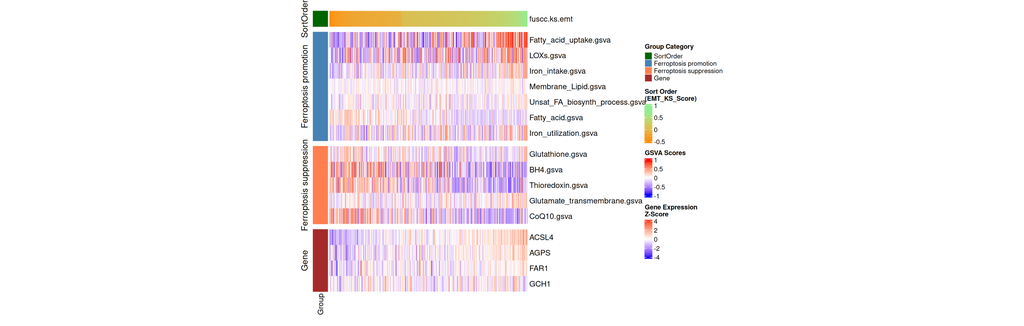

```r
# Or view in RStudio
draw(ht,
     annotation_legend_list = list(group_legend, sortorder_legend, ferroptosis_legend, gene_legend),
     annotation_legend_side = "right",
     padding = unit(c(1, 1, 1, 1), "cm"))
```

# Prepare Heatmap version 2

This version removes the genes from the plot. removes LOX and CoQ10, and reorders the gene sets

## Select data to plot

```r
merged_all.df <- merged_all %>% rownames_to_column("Sample")

heat.data <- merged_all.df %>%
  dplyr::select(all_of(c("Sample",
                         "fuscc.ks.emt",
                         "Fatty_acid_uptake.gsva","Iron_intake.gsva", "Membrane_Lipid.gsva", "Unsat_FA_biosynth_process.gsva", "Fatty_acid.gsva",
                         "Iron_utilization.gsva", "Glutathione.gsva",
                         "BH4.gsva", "Thioredoxin.gsva","Glutamate_transmembrane.gsva")))
```

```r
# Sort by EMT_KS_Score
heat.data.sorted <- heat.data[order(heat.data$fuscc.ks.emt), ]

# Define genes in order
genes_to_plot <- c("fuscc.ks.emt",
                   "Fatty_acid_uptake.gsva", "Unsat_FA_biosynth_process.gsva", "Fatty_acid.gsva", "Membrane_Lipid.gsva", "Iron_intake.gsva", "Iron_utilization.gsva",
                   "BH4.gsva","Thioredoxin.gsva","Glutathione.gsva","Glutamate_transmembrane.gsva")

# Create matrix
heatmap_data <- as.matrix(heat.data.sorted[, genes_to_plot])
heatmap_data <- t(heatmap_data)

# Define groups
group_vec <- c(
  "SortOrder",
  "Ferroptosis promotion", "Ferroptosis promotion", "Ferroptosis promotion","Ferroptosis promotion","Ferroptosis promotion","Ferroptosis promotion",
  "Ferroptosis suppression", "Ferroptosis suppression","Ferroptosis suppression", "Ferroptosis suppression")

# Create row split factor for spacing
row_split <- factor(group_vec,
                    levels = c("SortOrder", "Ferroptosis promotion",
                              "Ferroptosis suppression"))

# Create color functions
# Row 1: SortOrder
# Rows 2-11: Ferroptosis (10 rows)
ferroptosis_data <- heatmap_data[2:11, ]
sortorder_data <- heatmap_data[1, ]

# Ferroptosis color scale
ferroptosis_cols <- colorRamp2(c(min(ferroptosis_data), 0, max(ferroptosis_data)),
                                c("blue", "white", "red"))

# SortOrder color scale: orange to green
sortorder_cols <- colorRamp2(c(min(sortorder_data), max(sortorder_data)),
                              c("darkorange", "lightgreen"))

# Step 6: Create heatmap WITH left annotation for group bars
ht <- Heatmap(heatmap_data,
        cluster_rows = FALSE,
        cluster_columns = FALSE,
        row_split = row_split,
        row_gap = unit(3, "mm"),
        row_names_side = "right",
        show_column_names = FALSE,
        show_heatmap_legend = FALSE,
        left_annotation = rowAnnotation(
          Group = group_vec,
          col = list(Group = c("SortOrder" = "darkgreen",
                               "Ferroptosis promotion" = "steelblue",
                               "Ferroptosis suppression" = "coral")),
          show_legend = FALSE,
          simple_anno_size = unit(0.8, "cm"),
          gp = gpar(fontsize = 9)
        ),
        cell_fun = function(j, i, x, y, w, h, fill) {
          if(i == 1) {
            # SortOrder row
            fill_color <- sortorder_cols(heatmap_data[i, j])
          } else if(i <= 11) {
            # Ferroptosis rows
            fill_color <- ferroptosis_cols(heatmap_data[i, j])
          }
          grid.rect(x, y, w, h, gp = gpar(fill = fill_color, col = NA))
        },
        rect_gp = gpar(type = "none"),
        name = "Value",
        width = ncol(heatmap_data)*unit(0.8, "mm"),
        height = nrow(heatmap_data)*unit(9, "mm"))

# Create separate legends
group_legend <- Legend(at = c("SortOrder", "Ferroptosis promotion",
                              "Ferroptosis suppression", "Gene"),
                       labels = c("SortOrder", "Ferroptosis promotion",
                                  "Ferroptosis suppression"),
                       legend_gp = gpar(fill = c("darkgreen", "steelblue", "coral")),
                       title = "Group Category")

gene_legend <- Legend(col_fun = gene_cols,
                      title = "Gene Expression\nZ-Score",
                      direction = "vertical")

ferroptosis_legend <- Legend(col_fun = ferroptosis_cols,
                             title = "GSVA Scores",
                             direction = "vertical")

sortorder_legend <- Legend(col_fun = sortorder_cols,
                           title = "Sort Order\n(EMT_KS_Score)",
                           direction = "vertical")

# Step 8: Draw with legends
pdf("heatmap_v2.pdf", width = 22, height = 7)
draw(ht,
     annotation_legend_list = list(group_legend, sortorder_legend, ferroptosis_legend),
     annotation_legend_side = "right",
     padding = unit(c(1, 1, 1, 1), "cm"))
dev.off()
```

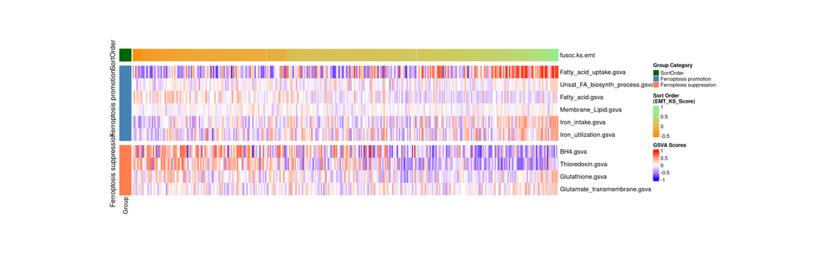

```r
# Or view in RStudio
draw(ht,
     annotation_legend_list = list(group_legend, sortorder_legend, ferroptosis_legend),
     annotation_legend_side = "right",
     padding = unit(c(1, 1, 1, 1), "cm"))
```

# Subset full data matrix to HER2+ based on expression of ERBB2

This group of samples can be defined using expression of ERBB2

## Examine expression of ERBB2

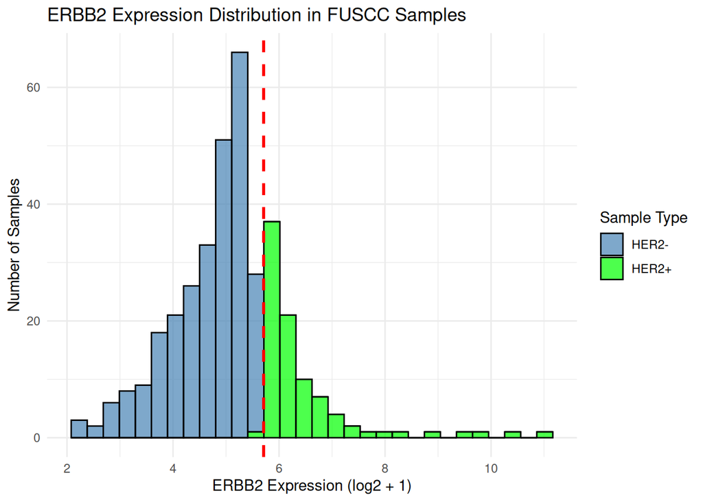

```r
# Extract ERBB2 expression values across all samples
erbb2_values <- expr_matrix["ERBB2", ]

# Calculate threshold
threshold <- quantile(erbb2_values, 0.75)
her2_positive_samples <- names(erbb2_values[erbb2_values > threshold])

data.frame(ERBB2 = erbb2_values) %>%
  mutate(group = ifelse(ERBB2 > threshold, "HER2+", "HER2-")) %>%
  ggplot(aes(x = ERBB2, fill = group)) +
  geom_histogram(bins = 30, color = "black", alpha = 0.7) +
  scale_fill_manual(values = c("HER2-" = "steelblue", "HER2+" = "green")) +
  geom_vline(aes(xintercept = threshold), color = "red", linetype = "dashed", linewidth = 1) +
  theme_minimal() +
  labs(title = "ERBB2 Expression Distribution in FUSCC Samples",
       x = "ERBB2 Expression (log2 + 1)",
       y = "Number of Samples",
       fill = "Sample Type")
```

```r
# Summary
cat(sprintf("HER2+ samples identified: %d / %d total (%.1f%%)\n",
            length(her2_positive_samples), length(erbb2_values),
            100*length(her2_positive_samples)/length(erbb2_values)))
```

```
## HER2+ samples identified: 90 / 360 total (25.0%)
```

```r
cat(sprintf("Threshold: %.3f\n", threshold))
```

```
## Threshold: 5.710
```

```r
writeLines(capture.output(sessionInfo()), "01_fuscc_dataImport_sessionInfo.txt")
```